# Linear regression introduction

# Weight, height and other covariates

## 1. Bivariate regression: outcome variable plus one predictor

> **To get us started on running our own regression models, let’s work with the data from the lecture on weight (in pounds), height (in inches), age and sex.** (This is data from Gelman et al’s “Regression and other stories” book.)

First, load the data. Either from the internet as here, or download via Blackboard, move to the working directory and load using `read.csv`.

```r
data <- read.csv(url('https://bit.ly/smi106weight'))
```

Let’s start just by looking at weight vs height. To begin with, let’s plot them. Note that in plot **we can use the “as a function of” ~ tilde operator**:

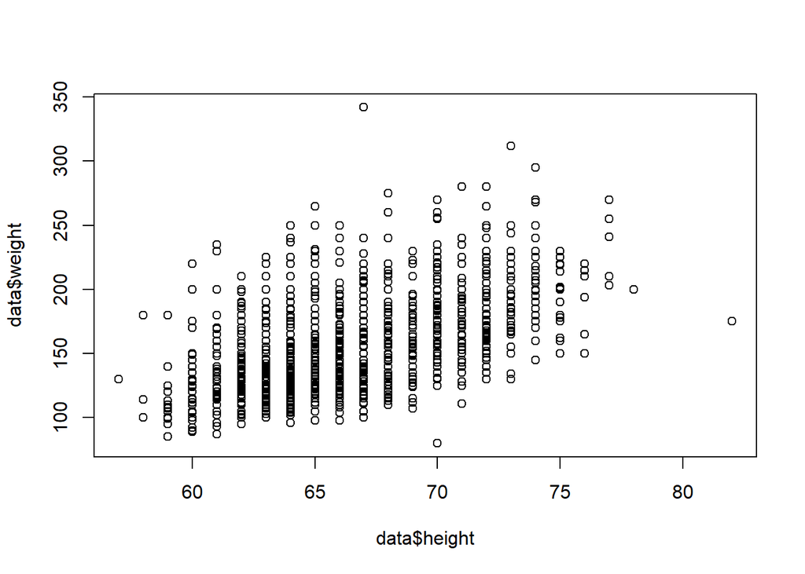

```r
plot(data$weight ~ data$height)
```

And to find the correlation coefficient (that ranges between -1 for perfect *negative* correlation to +1 for perfect *positive* correlation). Note: the order doesn’t matter for these arguments, the correlation is the same either way.

```r
cor(data$weight, data$height)
```

```
## [1] 0.5479932
```

> We can see there’s a relationship. Let’s use regression to quantify that relationship. We’ll create a **model** of how weight and height are connected.
- Weight will be our outcome variables
- Height is the predictor variable

So, **to model weight as a function of height**, we do this in R:

```r
lm(data$weight ~ data$height)
```

```
##
## Call:
## lm(formula = data$weight ~ data$height)
##
## Coefficients:
## (Intercept)  data$height
##    -172.264        4.933
```

We can also do this if we don’t want to use the full column names: **tell `lm` what the data is, then just use the plain column names**. I’ll do this from now on, it’s a little tidier to read:

```r
lm(data = data, weight ~ height)
```

Recall this is the regression equation for two variables:

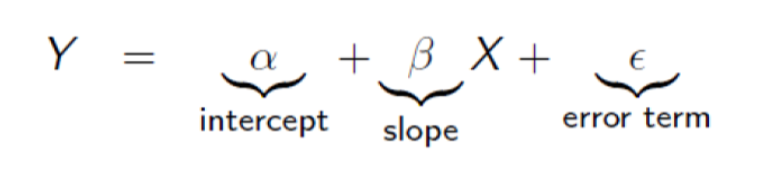

So, the **model coefficients** that R outputs are the **intercept** and **slope** from this equation, respectively.

They tell us the following:

- The intercept is **the value of y when x = 0.** So according to this model, when height is 0 inches, weight is minus 172 pounds. This is not meaningful for us - zero height doesn’t make sense. **It’s often the case that the intercept has no meaning and doesn’t matter to what we’re trying to investigate**. We have to use our prior knowledge to judge this, and work out if we want to make any adjustments to the data to make the intercept meaningful.
- The “height” coefficient is **4.933**.

Plugging those into the equation, our **model** for how weight is function of height looks like this:

$weight_i = -172.264 + (4.933 * height_i)$

> So: y is 4.933 * x. **For every one inch increase in height, the model says we get a 4.933 pound increase in weight.** (I have to tell it to myself like this most times - interpreting coefficients isn’t always easy / can take some squinting at.)

If we **store the output of the regression model from the lm function**, we can do a few more useful things. **Assign to an object in the usual way to do this:** Let’s just call the object *model* and use our previous `lm` code:

```r
model <- lm(data = data, weight ~ height)
```

First-off, we can **use this to add the slope line to the plot of the data we did above. The `abline` function just means the `a b line` where a is the intercept and b the slope.** `abline` will add it to the previous plot. (I’m including plot again here, but you shouldn’t need to.)

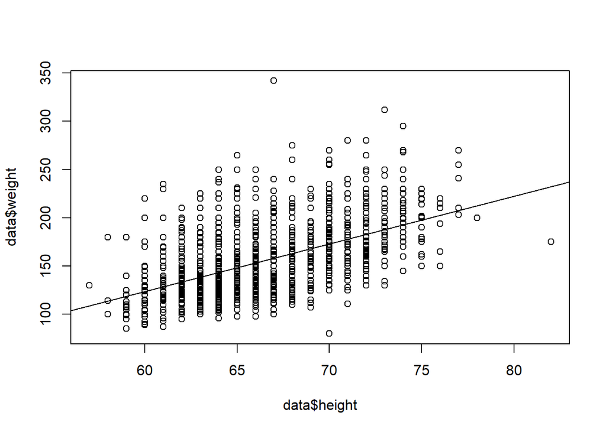

```r
plot(data$weight ~ data$height)
abline(model)
```

> **This line is our model for the relationship between the outcome and the predictor. The model would predict datapoints would all fall on that line. The “error” in the model is the distance between that line and the actual data points we have.**

We also also output a **much more detailed summary**. As I mentioned in the lecture, we’ll talk through most of the details here in later weeks. **For now, let’s just check what the $R^2$ is:**

```r
summary(model)
```

```
##
## Call:
## lm(formula = weight ~ height, data = data)
##
## Residuals:
##     Min      1Q  Median      3Q     Max
## -93.054 -18.573  -3.723  12.080 183.745
##
## Coefficients:
##              Estimate Std. Error t value Pr(>|t|)
## (Intercept) -172.2635    11.8914  -14.49   <2e-16 ***
## height         4.9331     0.1783   27.67   <2e-16 ***
## ---
## Signif. codes:  0 '***' 0.001 '**' 0.01 '*' 0.05 '.' 0.1 ' ' 1
##
## Residual standard error: 28.91 on 1784 degrees of freedom
## Multiple R-squared:  0.3003, Adjusted R-squared:  0.2999
## F-statistic: 765.7 on 1 and 1784 DF,  p-value: < 2.2e-16
```

We can see $R^2$ is telling us that **height is explaining 30% of the variation in weight**.

## 2. Regression with two predictors

What effect does **age** have on weight, controlling for height? “For any group of people who are the same height, how much difference does *age* make to their weight, on average?”

With three variables - one outcome and two predictors - it’s still just about possible to visualise the data. To do this, we can use an interactive 3D plotter from the `plotly’ library. I’m not going to run it on this machine as I think it crashes university computers, but if you want to try:

- First install the library and load it:

```r
install.packages('plotly')
library(plotly)
```

The following will allow you to view an interactive 3D plot of 3 variables. Note the use of tildes in the arguments.

Note also: **we’re taking a sample of rows from the dataset** so the pattern is easier to visualise and the data loads and runs easily. We’ll use a **handy tidyverse function** to sample 300 rows. Load the tidyverse library first. (Note, we have to **set weight to z** for it to appear on the vertical axis.)

```r
library(tidyverse)

p <- plot_ly(data = sample_n(data,300), z = ~weight, x = ~height, y = ~age, opacity = 0.6)

add_markers(p)
```

For this plot, you can **drag the view around with the mouse** and **make larger by clicking zoom in the viewer pane**.

Sometimes it’s useful to get a look at the data like this, to see if relationships are clear.

> **Now we’ll use regression to model weight as a function of height plus age.**

We can model this by **adding age as a predictor to the regression**:

```r
lm(data = data, weight ~ height + age)
```

```
##
## Call:
## lm(formula = weight ~ height + age, data = data)
##
## Coefficients:
## (Intercept)       height          age
##   -199.7622       5.1333       0.3301
```

- **Weight increases a third of a pound for every one year of age**, controlling for height.
- Or: “For any group of people who are the same height, those who are a year older will be a third of a pound heavier on average.”

## Adding a categorical/factor variable to the model

Suppose we want to know **how weight differs for men and women** - but not just the average weight difference, which is going to be mainly affected by the average male/female height difference. Instead we want to know: “for men vs women of the same height and age, how does weight differ on average?”

We can **control for height and age** and put male/female in as another predictor.

- Because it’s a categorical variable, it will go in as a **dummy variable** and give us a model where the coefficient tells us the **difference between men and women’s weight, controlling for height and age**.

We can see that the `male` column in the dataset is just 1 and 0 using `table`:

```r
table(data$male)
```

```
##
##    0    1
## 1112  674
```

And if we just check the mean height differences for those two using `tapply`:

```r
tapply(data$height, data$male, mean)
```

```
##        0        1
## 64.47122 70.08605
```

That confirms (presuming this is a representative sample) that `male` is 1 and `female` is zero.

- A zero value will be the **reference category in a regression** by default.
- We can control this with factors, as we saw in the lecture, but let’s use the `male` variable as is:

**Adding the `male` binary variable to the model:**

```r
lm(data = data, weight ~ height + age + male)
```

```
##
## Call:
## lm(formula = weight ~ height + age + male, data = data)
##
## Coefficients:
## (Intercept)       height          age         male
##   -136.6791       4.1292       0.3203      11.1363
```

- **Our new `male` coefficient is 11.1363.**

This is telling us the **difference in weight** for men compared to women (the reference category) **when controlling for height and age**.

- **Weight is higher by 11.13 pounds for men over women**, controlling for height and age.
- Or: “For any group of people who are the same height and age, men are 11.13 pounds heavier than women.”

Again, we can check how much of the variation in weight is being explained by our model by assigning to an object and looking at the summary:

```r
model <- lm(data = data, weight ~ height + age + male)

summary(model)
```

```
##
## Call:
## lm(formula = weight ~ height + age + male, data = data)
##
## Residuals:
##     Min      1Q  Median      3Q     Max
## -91.905 -18.477  -4.749  11.608 185.366
##
## Coefficients:
##               Estimate Std. Error t value Pr(>|t|)
## (Intercept) -136.67906   16.31765  -8.376  < 2e-16 ***
## height         4.12922    0.24802  16.649  < 2e-16 ***
## age            0.32030    0.03913   8.186 5.09e-16 ***
## male          11.13628    1.94909   5.714 1.29e-08 ***
## ---
## Signif. codes:  0 '***' 0.001 '**' 0.01 '*' 0.05 '.' 0.1 ' ' 1
##
## Residual standard error: 28.11 on 1782 degrees of freedom
## Multiple R-squared:  0.3389, Adjusted R-squared:  0.3378
## F-statistic: 304.5 on 3 and 1782 DF,  p-value: < 2.2e-16
```

- **Because this model has more than one predictor in, we use the *adjusted $R^2$*** .
- This is 0.3378, so 33.78% of weight’s variation is explained by our three predictors, height, age and male/female.

# Co-ethnic Candidates and Voter Turnout

Now let’s look at a more serious dataset. We will analyse data from the following article:

Fraga, Bernard. (2015) [“Candidates or Districts? Reevaluating the Role of Race in Voter Turnout,”](http://dx.doi.org/10.1111/ajps.12172) *American Journal of Political Science*, Vol. 60, No. 1, pp. 97–122.

Fraga assesses the theory that minority voters in America are more likely to vote in elections featuring candidates of their own ethnicity (or “co-ethnic candidates”). He shows that the association between minority voter turnout and co-ethnic candidates **disappears** once we take into account district-level racial composition. In particular, he demonstrates that in districts where black people make up a greater share of the voting-age population, black people in that district are more likely to vote in elections *regardless* of candidate race.

Fraga analyses turnout data for four different racial and ethnic groups, but **for this analysis we will focus on the data for black voters only**.

A description of the variables is listed below:

| Name | Description |
| --- | --- |
| `year` | Year the election was held |
| `state` | State in which the election was held |
| `district` | District in which the election was held (unique within state but not across states) |
| `turnout` | The proportion of the black voting-age population in a district that votes in the general election |
| `CVAP` | The proportion of a district’s voting-age population that is black |
| `candidate` | Binary variable coded “1” when the election includes a black candidate; “0” when the election does not include a black candidate |

> A note on one of these variables: “The proportion of the black voting-age population in a district that votes in the general election”. **This is *not* proportion of black voters in a district**. Of the proportion of *possible* black voters, this variable is the **proportion of those that did vote**. This will be important shortly!

## Task 1

- **Load the data**, either via the internet with the line of code below, or copy from Blackboard and put in your data folder.

```r
df <- read.csv(url('https://bit.ly/smi106week5'))
```

If loading from a data folder in your working directory:

```r
df <- read.csv("data/blackturnout.csv")
```

> **EXERCISE: Which years are included in the dataset? How many different states are included in the dataset? (You can use the `summary`, `unique` and `length` functions to find these out.)**

## Task 2

To see if there’s a difference in voter turnout based on whether there’s a co-ethnic candidate in the district, let’s **make a boxplot** that compares turnout in elections with and without a co-ethnic candidate.

Before we do that, let’s just check what the `candidate` variable looks like:

```r
table(df$candidate)
```

```
##
##    0    1
## 1089  148
```

We’ve got a lot more districts with elections **without** a black candidate.

We can make a boxplot using **base R** using the following code. Note we’re using our tilde again, so we’re asking R to give us a boxplot where turnout *is a function of* whether any black candidates were running in the election.

**Feel free to use your tidyverse knowledge to make a similar boxplot**.

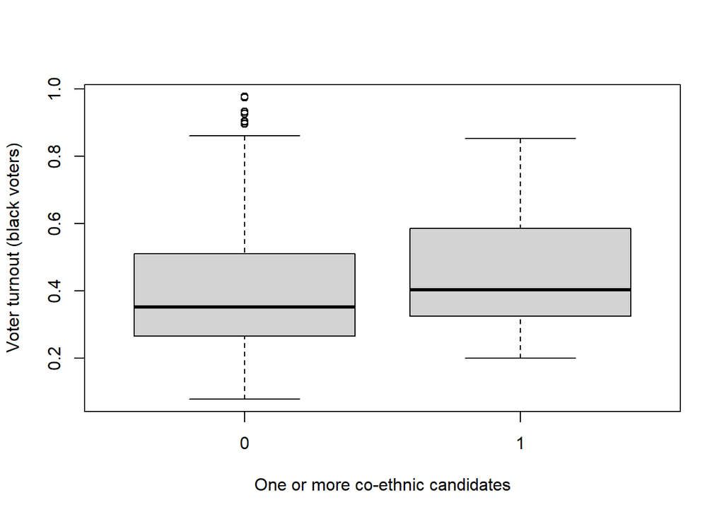

```r
boxplot(turnout ~ candidate, data = df,
        ylab = "Voter turnout (black voters)",
        xlab = "One or more co-ethnic candidates")
```

We find that **black turnout tends to be higher when a co-ethnic candidate is running.** But is that the full story?

## Task 3

We’ll run a linear regression with **black turnout as our outcome variable** and candidate **co-ethnicity as the predictor**.

- We’ve got a **binary predictor** here, that’s going to tell us the **difference to the base category of “no co-ethnic candidates”**.

```r
lm(data = df, turnout ~ candidate)
```

```
##
## Call:
## lm(formula = turnout ~ candidate, data = df)
##
## Coefficients:
## (Intercept)    candidate
##     0.39386      0.06164
```

This is just a simple two-variable regression model, so plugging those numbers in, we get:

$\text{turnout as a proportion of black people in district} = 0.394 + 0.062 * \text{whether election has black candidate running}$

- The intercept is 0.394, which means that in elections featuring no black candidates, 39.4% of the black voting-age population are predicted to turn out.
- The coefficient on the candidate co-ethnicity variable is 0.062. This is a **binary variable** - it’s either zero or 1. If it’s zero, the coefficient of 0.062 * 0 is just zero. If it’s one, it’s just 0.062 - so that constant is added to the Y side of the equation.
- So: in elections with a black candidate, black voter turnout is predicted to be about 6.2% percentage points higher on average.
- The intercept is meaningful here: we can add the `candidate` coefficient to it to find, for elections featuring at least one black candidate, black voter turnout is predicted to be: 45.6%.

**These results are consistent with what the boxplot was showing us, that black voters turn out at a higher rate when a co-ethnic candidate is running.**

## Task 4

Let’s investigate the results of the previous question a bit more carefully: elections with co-ethnic candidates may differ from the elections without co-ethnic candidates in other ways.

- To try and see what’s going on, we’ll create a scatter plot where the x-axis is the proportion of black voting-age population and the y-axis is black voter turnout.
- We’ll colour points according to candidate ethnicity - that is, make the points for elections featuring co-ethnic candidates one colour, and make the points for elections featuring no co-ethnic candidates a different colour.

> **Have a go at coding in one of the following two: either the base-R version, or the tidyverse version.**

In the base-R one we’ll do some extra variable creation so the plot can easily read off colours for the points.

- **Base R version:**

```r
df$col[df$candidate == 0] <- "blue"
df$col[df$candidate == 1] <- "red"

plot(df$CVAP, df$turnout, col = df$col,
     xlab = "Black Voting-Age Population",
     ylab = "Black Voter Turnout")

legend(.37, .95,
       legend = c("Co-ethnic Candidate", "No Co-ethnic Candidates"),
       col = c("red", "blue"), pch = c(1, 1))
```

[output not shown]

- **Tidyverse version**

```r
ggplot(df, aes(x = CVAP, y = turnout, colour = factor(candidate))) +
  geom_point(size = 2, shape = 1) +
  xlab("Black Voting-Age Population") +
  ylab("Black Voter Turnout")
```

- First, it shows that black candidates often run in districts that have large black voting-age populations (which is unsurprising: there are larger numbers of potential black candidates there).
- Second, it looks like there is a positive relationship between “proportion of a district’s voting-age population that is black” and “proportion of the black voting-age population in a district that votes in the general election”. (Note: that’s *not* just the obvious relation to number of black voters and proportion of district that is black.)

We’ve seen that there’s a **higher proportion black voting turnout when there’s at least one black candidate running**. But that plot shows also that **there’s higher black voting turnout (*as a proportion of the black voting age population*, remember) in districts with larger black populations.** *It may not be the presence or otherwise of co-ethnic candidates that’s making the difference.*

> **QUICK EXERCISE: Using the `cor` function, just check what the actual correlation coefficient is for black voting age population and black voter turnout.**

## Task 5

```r
lm(data = df, turnout ~ candidate + CVAP)
```

```
##
## Call:
## lm(formula = turnout ~ candidate + CVAP, data = df)
##
## Coefficients:
## (Intercept)    candidate         CVAP
##    0.375275    -0.007364     0.207392
```

**Let’s look at the model equation we’re using here to help interpret the output from that model:**

$turnout = -0.007 * \text{election featuring a black candidate} + 0.207 * \text{proportion of black people in district of voting age}$

An extra couple of notes on interpreting:

- It can take quite a lot of staring and figuring out. It may come intuitively to some - for me at least, I generally have to check the equation, think about “Y = B * X” or “turnout = beta * proportion black people”, think about the fact that the coefficient tells us: “for a one unit increase/decrease in our variable, Y increases/decreases by beta”.

## Task 6

> **Exercise: can we interpret the *intercept* from this two-predictor regression model? ($\alpha = 0.375$) Is this intercept meaningful here? Is it a substantively important or interesting quantity? Why or why not?**
- Reminder: if our predictors haven’t been adjusted, the intercept is “the value of Y when predictors equal zero”. So in this case, Y = “the value of black voter turnout (as a proportion of black voters in that district) when there’s both no black candidate and zero proportion black people in the district.”

## Task 7

> **EXERCISE: Run the same regression again but assign to an object, and then check the summary to see what the adjusted $R^2$ is. How much variation in turnout is being explained by the proportion of black people in the district and the co-ethnicity of running candidates? What are your thoughts on what this could mean for the model?**

## Task 7

We’ve just seen **two different models**, one with just a single predictor, another with two of them.

> **EXERCISE: How did the ‘co-ethnic / black candidates running in the election’ coefficient change between the two models? What did each of them say about its relationship to the proportion of the black voting-age population in a district that votes in the general election? Do you think those answers are likely to be significant?** (We’ll be talking about a more precise answer to that question in the coming two weeks.)